# Using RMarkdown

July 12, 2014

### Text

Text can decorated with **bold** or *italics*. It is also possible to

- create [links](http://rmarkdown.rstudio.com/)
- include mathematics like $e=mc^2$ or $y = \beta_0 + \beta_1 x_1 + \beta_2 x_2$
- embed images

Be sure to put a space after the * when you are creating bullets and a space after # when creating section headers, but **not** between $ and the mathematical formulas.

### Graphics

If the code of an R chunk produces a plot, this plot can be displayed in the resulting file.

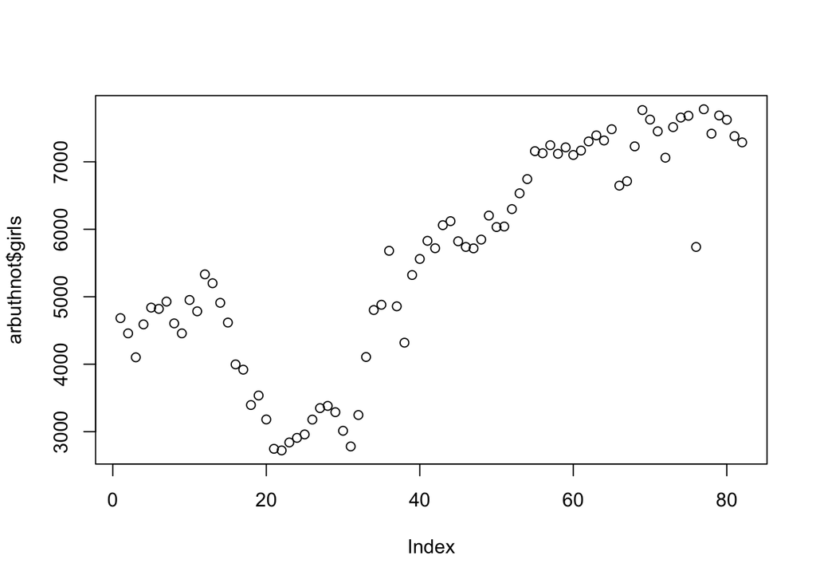

```r
source("http://www.openintro.org/stat/data/arbuthnot.R")
plot(arbuthnot$girls)
```

### R output

Other forms of R output are also displayed as they are produced.

```r
head(arbuthnot$girls)
```

```
## [1] 4683 4457 4102 4590 4839 4820
```

You can also use “chunk options” to modify how your R chunks work. We can hide the code:

```
##    Min. 1st Qu.  Median    Mean 3rd Qu.    Max.
##    2720    4460    5720    5530    7150    7780
```

Or we can hide the output:

```r
summary(arbuthnot$girls)
```

### In-text Code

In a similar vein, you can refer to R code in a paragraph by setting it off with single ticks, say if we wanted to mentioned that we had used the `summary()` function. You can also put R output directly into text, as in: the mean number of births was 5534.6463.

### Destination formats

This file can be knit to HTML, PDF, or Word. In RStudio, just select the desired output file type and click on `Knit HTML`, `Knit PDF`, or `Knit Word`. Use the dropdown menu next to that to change the desired file type.